# R plots

Plots

2019-02-27

Often you get more information about a data.set by making graphs than by making tables. Here we will show some basic commands that R provides for this. In R there are several packages for creating plots. The main ones are: * graphics * lattice * ggplot2 Here we will discuss the base graphics from the graphics library. This package is the oldest of the graphical packages, it comes with the R installation (so you do not have to use `install.packages`), and is loaded automatically when R starts. For these reasons the type of graphics it creates are called ‘base’ plots. The plotting functions in the `graphics` package can be divided in two types. The so called higher-level plotting functions and the lower-level plotting functions. The distinction is that the former create a more or less complete plot while the latter perform very specific functions (like adding specific points at certain locations, adding a legend and so on). Often we build complicated functions step by step by first using a higher-level plotting function and then adding thing to it using lower-level plotting functions.

## Histograms

If we want to learn something about the distribution of a single continous variable we can make a histogram. In R this is done using the function `hist`. Let’s look at the pain score at the follow-up.

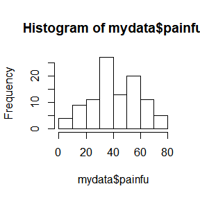

```r
hist(mydata$painfu)
```

If we run this code in RStudio the plot is displayed in the bottom right-hand corner. From there we can save the plot as an pdf, or image file by clicking ‘export’ if we want to keep it. We can have more control over the number of bins that is used by using the `breaks` parameter.

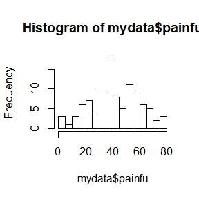

```r
hist(mydata$painfu, breaks=20)
hist(mydata$painfu, breaks=seq(0,80,5))
```

## Pie charts, bar charts and dot charts

When we look at a single categorical variable a pie chart is often used to see how the observations are divided over the levels of the variable. The `pie` function takes a numeric vector of frequencies as input (together with a set of labels). It is often more convenient to work with a table.:

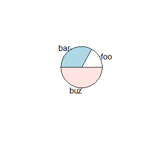

```r
pie(c(2, 4, 6), labels=c('foo', 'bar', 'buz') )
```

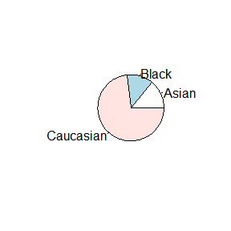

```r
pie(table(mydata$race))
```

Some people recommend against using pie charts because people are bad at judging relative areas. Often a so called dotchart is suggested as an alternative.

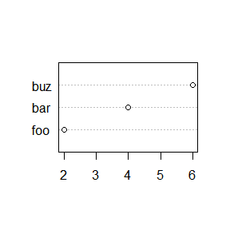

```r
dotchart(c(2, 4, 6), labels=c('foo', 'bar', 'buz') )
```

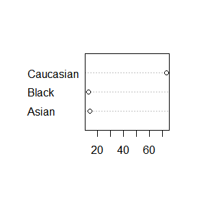

```r
dotchart(c(table(mydata$race)))
```

Note that we were required to transform the table to a vector by using the function `c`. Instead of a vector we can also use a matrix (or a two dimensional table which can readily be converted to it) as input for the function.

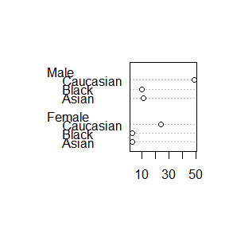

```r
dotchart(table(mydata$race, mydata$sex))
```

An other alternative for this type of data is a bar chart (which resembles a histogram but the x-axis is not a continuous scale but instead represents the different levels of the variable). In R we use the command `barplot`. The names of the categories are now specified using the parameter ‘names.arg’ instead of ‘labels’.

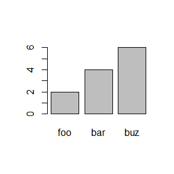

```r
barplot(c(2, 4, 6), names.arg =c('foo', 'bar', 'buz')  )
```

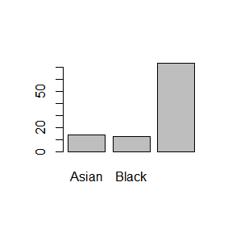

```r
barplot(table(mydata$race))
```

We can also use a matrix or 2-dimensional table.

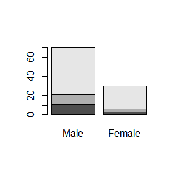

```r
barplot(table(mydata$race, mydata$sex))
```

It would be better to add a legend to the plot to explain what the colors mean. We will come back to that later. It is also possible to unstack the different categories using

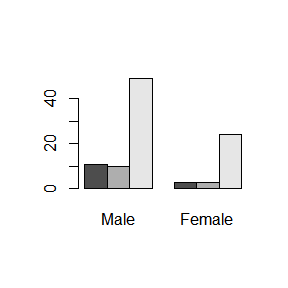

```r
barplot(table(mydata$race, mydata$sex),beside = TRUE)
```

## Scatterplots

If we want to look at the relation between two variables we can use the `plot` command to make a scatter plot.

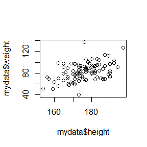

```r
plot(mydata$height, mydata$weight)
```

If we use only a single input vector the values are plotted against the observation numbers (which is not very useful here).

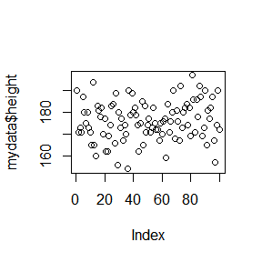

```r
plot(mydata$height)
```

Sometimes we want to study the relation ship between several continuous variables at the same time. In this case we can make a scatter plot matrix. As the name implies this is basically a matrix of scatter plots with the scatter plots of all pairwise combinations of variables as off-diagonal elements.

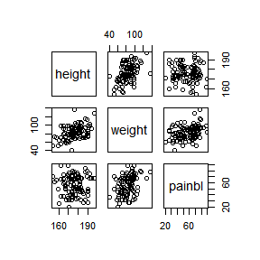

```r
pairs(~height+weight+painbl, data=mydata)
```

## Common elements to plot commands

The plots above were very basic and we can do much to improve them by adding colors, changing the thickness and style of the lines and so on. Many of these things can be done by using extra parameters of the plotting function. For example `plot(mydata$height, col='red')`. A number of parameters (like `col` to set the color or `lwd` to set the thickness of lines) is common to most of the plotting commands discussed above and I will discuss the most important ones here.

Another way to set these plotting parameters is through the function `par`. For example: `par(col='red')` Some of the plotting parameters (like `mar` and `mfrow`) can even only be set in this fashion. A difference between using the parameters on the plot functions themselves is that when they are used in the plot functions they change an attribute for the current plot only but when they are used on the `par` function they change the attribute for all following plots.

### col

The parameter `col` can often be used to specify what collor to use to plot something. There are several ways do do this. The first is by using the name of the color. You can see all available color names by specifying the `colors()` function.

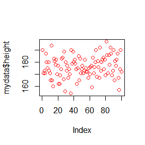

```r
plot(mydata$height, col='red')
```

We can also use integers to specify the colors. The integers refer to positions in the current color palette. By default 1 is black, 2 is red, 3 is green, 4 is blue, 5 is cyan, 6 is magenta, 7 is yellow and 8 is grey. The color palette can be viewed or changed using the `palette` function. Finally we can specify colors by using a string representing the hexadecimal (that is 16-base, one does not use the normal 10 digits but the 16 ‘digits’ 0, 1, 2, 3, 4, 5, 6, 7, 8, 9, A, B, C, D, E and F) color values. Basically this is a string where the first two characters indicate how strong the red signal is on a scale from 0-255 the next two characters indicate how strong the green signal is and the last two characters indicate how strong the blue signal is.

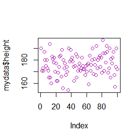

```r
plot(mydata$height, col='#AA11AA')
```

### pch

pch indicates the ‘plot character’. Usually an integer is used. Each number stands for a specific symbol.

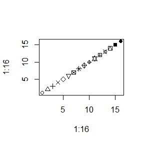

```r
plot(x=1:16, 1:16, pch=1:16)
```

### cex

This parameter specifies how large symbols and text should be.

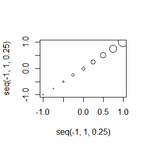

```r
plot(x=seq(-1,1,0.25), y=seq(-1,1,0.25), cex=exp(seq(-1,1,0.25)))
```

### lwd

The parameter lwd indicates how thick the lines should be.

### lty

This parameter indicates the line type: 1 is solid, 2 is dashed and 3 dotted. More complex patterns are also possible (see ?par).

### xlim / ylim

Limits of the x and y axis. By default a little bit of extra space is added so the extreme values do not fall at the very edge of the plot.

### xlab / ylab

Labels of the x and y axis

### main

This parameter can be used to set the title of a plot. It is an alternative for the `title` command (See below).

### mar

This graphical parameter indicates the size of the margins in the plot. The argument should take the form of a numerical vector of length 4 (exactly). The margins should be specified in the order: lower margin, left margin, upper margin and right margin. Note that this parameter can only be set using `par`.

### mfow

This parameter controls the number of subplots. Normally there is only a single subplot but this can be changed. The parameter `mfow` takes a vector of length 2. The first number specifies the number of rows of subfigures and the second the number of columns of subfigures.

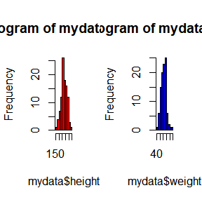

```r
opar <- par(mfrow=c(1, 2))
hist(mydata$height, col='red')
hist(mydata$weight, col='blue')
```

```r
par(opar)
```

Notice how the return value of the par function can be used to restore all plotting parameters to their defaults.

## some lower-level plot functions

As mentioned above the lower-level plot functions do not create a complete plot but instead they perform a very specific task. Common lower-level plotting functions are:

### points(x, y, …)

To add points to a plot.

### lines(x, y, …)

To add lines to a plot.

### text(x, y, …)

To add texts to a plot.

### abline(…).

This function can be used to add reference lines. Horizontal lines can be added using `abline(h=y)` were y is the y coordinate of the line. Vertical lines can be drawn using `abline(v=x)`. Finally a diagonal line with equation $y=a+bx$ can be drawn using `abline(a=a, b=b)` (This is were the name of the function comes from).

### legend(x, y, legend, …)

With this function we can add a legend to a plot. Besides using x and y coordinates for the plot we can also indicate the position using text values as ‘top’, ‘bottom’, ‘left’ and ‘right’.

### title(main, sub, …)

This function can be used to add a title and a subtitle to a plot.

### polygon(x, y, border, col,…)

Draws a polygon. THis works the same way as the lines command but the end is connected with the beginning. The parameter `col` specifies the color with which the polygon will be filled while `border` specifies the color of the border.

### segments(x0, y0, x1, x1, …)

Draws line segments from the points (x0, y0) to (x1, y1). Unlike the function `lines` the lines are not automatically connected.

Examine the code below and the resulting plot. We use many of the above functions and some additional ones. Most commands should be relatively self explanatory. Otherwise you can always use the documentation.

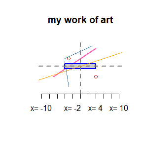

```r
plot.new()
plot.window(xlim=c(-10,10), ylim=c(-10, 10))
points(c(-3, 4), c(3, -4), col= 'red')
lines(c(4, -7), c(7, -4), lwd=2,
      col= 'hotpink')
segments(x0=c(-4, -4), x1=c(3,-3), y0=c(3,2), y1=c(8,-8),
         col='steelblue')
polygon(c(4,4,-4,-4), c(-1,1,1,-1),
        border = 'blue', col = '#BBBBBBBB', lwd=2)
abline(v=0, lty=2, lwd=2, col='grey50') # vertical line x=0
abline(h=0, lty=2, lwd=2, col='grey50') # horizontal line y=0
abline(a=0, b=0.5, col='orange') # line denifed by y=a+bx
title('my work of art')
axis(side = 1, at = seq(-10,10, 2),
     labels=paste('x=',seq(-10,10, 2)))
```

### Illustration of a the creation of a (somewhat) complicated plot

While the plot above shows a lot of different low-level commands. The resulting plot is not very useful. Below we show a more practical example: some code that was used to generate an illustrate of the normal distribution.

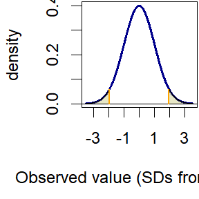

```r
x <- seq(-3.5, 3.5, 0.005)
y <- dnorm(x, 0,1)
par(mar=c(4.6,4.1,0.1,0.1), cex=1.5)
plot(x=x,y=y, col='darkblue', type='l', lwd=3,
     xlab='Observed value (SDs from mean)', ylab='density')
q <- qnorm(0.025, 0, 1)
p <- dnorm(q, 0, 1)
abline(h=0)

cord.x <- c(-3.5, seq(-3.5, q, 0.005),  q)
cord.y <-c(0, dnorm(seq(-3.5,q, 0.005),0,1),0)
polygon(cord.x,cord.y,col='#BABA5555')
cord.x <- c(3.5, seq(3.5, -q, -0.005),  -q)
cord.y <-c(0, dnorm(seq(3.5,-q, -0.005),0,1),0)
polygon(cord.x,cord.y,col='#BABA5555')

lines(x=c(q, q), y=c(0, p), col= 'orange', lwd=2 )
lines(x=c(-q, -q), y=c(0, p), col= 'orange', lwd=2 )
```